# Regression and model validation

*Describe the work you have done this week and summarize your learning.*

- Describe your work and results clearly.
- Assume the reader has an introductory course level understanding of writing and reading R code as well as statistical methods.
- Assume the reader has no previous knowledge of your data or the more advanced methods you are using.

```r
date()
```

```
## [1] "Thu Nov 05 23:10:02 2020"
```

Here we go again…

## Loading and inspecting the data

I have created a dataset, which is a subset of learning related data by Kimmo Vehkalahti. I will load the dataset and inspect it’s dimensions:

```r
lrn14 <- read.csv("data/learning2014.csv", sep = ",", header = T)
dim(lrn14)
```

```
## [1] 166   7
```

Let’s inspect the structure as well:

```r
str(lrn14)
```

```
## 'data.frame':    166 obs. of  7 variables:
##  $ gender  : chr  "F" "M" "F" "M" ...
##  $ age     : int  53 55 49 53 49 38 50 37 37 42 ...
##  $ attitude: int  37 31 25 35 37 38 35 29 38 21 ...
##  $ deep    : num  3.58 2.92 3.5 3.5 3.67 ...
##  $ stra    : num  3.38 2.75 3.62 3.12 3.62 ...
##  $ surf    : num  2.58 3.17 2.25 2.25 2.83 ...
##  $ points  : int  25 12 24 10 22 21 21 31 24 26 ...
```

This dataset has 166 observations of 7 variables. The variable names are gender, age, attitude, deep, stra, surf, and points. Gender and age are quite self explanatory. Attitude measures student’s global attitude towards statistics. Deep, stra, and surf are combined variables of deep, strategic, and surface learning approaches, respectively. Points refers to exam points.

Let’s visualise the data to see how it looks. I’m plotting all possible scatter plots from the columns of the data. The first column, gender, does not have numerical values, so I’m excluding it.

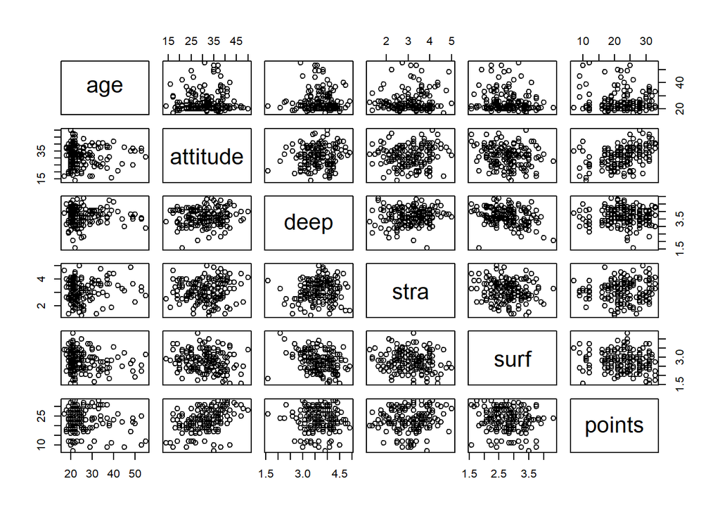

```r
pairs(lrn14[-1])
```

This gives a basic idea of how the data look. If we want a more detailed visualisation of the variables and their distributions, we can use ggpairs(). To use that, we need to access GGally and ggplot2 libraries.

```r
library(GGally)
```

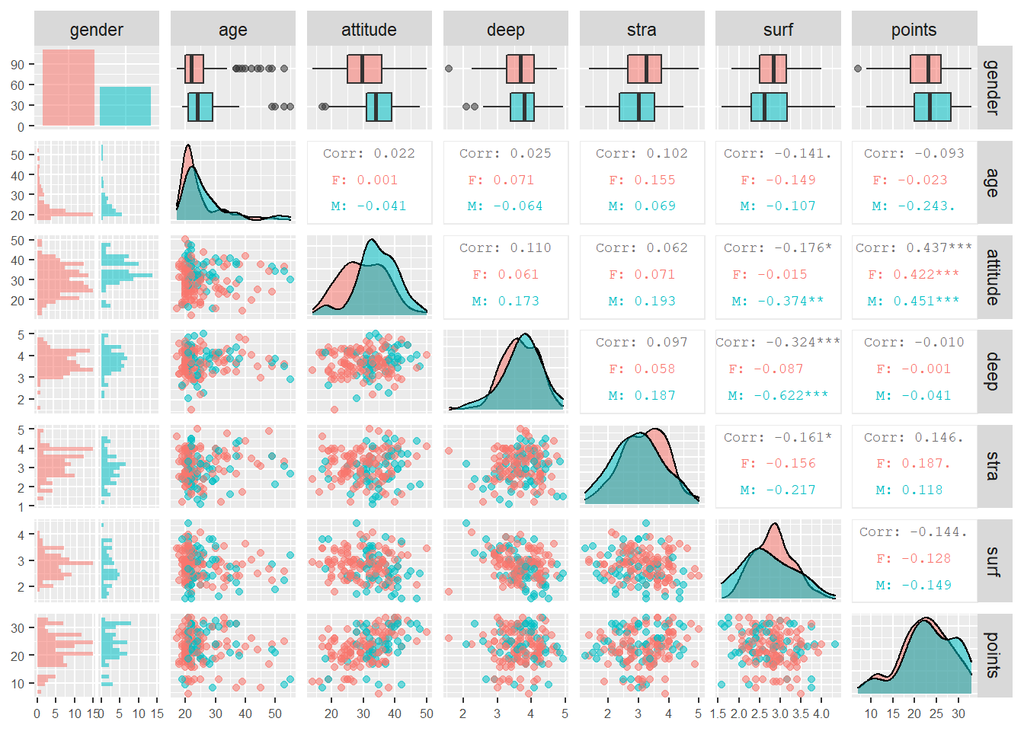

```r
library(ggplot2)

# Create more detailed plot.

p <- ggpairs(lrn14,
             mapping = aes(col = gender, alpha = 0.4),
             lower = list(combo = wrap("facethist", bins = 20)),
             upper = list(continuous = wrap("cor", size = 2.5))) + theme(axis.text.x = element_text(size = 6),
      axis.text.y = element_text(size = 6))

# Draw the plot.
p
```

Here we have the colours defined by gender.

Let’s check the summaries as well:

```r
summary(lrn14)
```

```
##     gender               age           attitude          deep
##  Length:166         Min.   :17.00   Min.   :14.00   Min.   :1.583
##  Class :character   1st Qu.:21.00   1st Qu.:26.00   1st Qu.:3.333
##  Mode  :character   Median :22.00   Median :32.00   Median :3.667
##                     Mean   :25.51   Mean   :31.43   Mean   :3.680
##                     3rd Qu.:27.00   3rd Qu.:37.00   3rd Qu.:4.083
##                     Max.   :55.00   Max.   :50.00   Max.   :4.917
##       stra            surf           points
##  Min.   :1.250   Min.   :1.583   Min.   : 7.00
##  1st Qu.:2.625   1st Qu.:2.417   1st Qu.:19.00
##  Median :3.188   Median :2.833   Median :23.00
##  Mean   :3.121   Mean   :2.787   Mean   :22.72
##  3rd Qu.:3.625   3rd Qu.:3.167   3rd Qu.:27.75
##  Max.   :5.000   Max.   :4.333   Max.   :33.00
```

The data contains more women than men. The age range in the data is 17-55 years. The distributions between men and women differ most in the attitude towards statistics.

The strongest overall correlation is between attitude and points **(*r*=.437)**. This correlation is also found in both genders separately. The second strongest correlation is between surface and deep learning approaches **(*r*=-.324)**. This correlation, however, exists only for men when the gender groups are examined separately.